# Tugas Praktikum 3 MPDW - Regresi dengan Peubah Lag

Pingkan Febbe Fiorela Kereh

2023-09-17

## *Packages*

Berikut adalah beberapa packages yang digunakan:

```r
library(dLagM)
library(dynlm)
library(MLmetrics)
library(lmtest)
library(car)
library(rio)
```

## Input Data

Data yang digunakan adalah data Air Quality Index (AQI) di New Delhi. Data ini terdiri dari 72 observasi (baris) dan 12 variabel (kolom).

```r
aqi <- import("https://raw.githubusercontent.com/pingkanfebbe/MPDW/main/Pertemuan%203/New%20Delhi%20AQI%20dataset.csv")
str(aqi)
```

```
## 'data.frame':    72 obs. of  12 variables:
##  $ V1             : int  0 1 2 3 4 5 6 7 8 9 ...
##  $ AQI            : num  30.2 28.2 26.6 25 26 26 26 24 23 24 ...
##  $ CO             : num  199 198 199 202 205 ...
##  $ datetime       : chr  "2022-10-21:18" "2022-10-21:19" "2022-10-21:20" "2022-10-21:21" ...
##  $ no2            : num  0.0469 0.0465 0.0469 0.0482 0.0489 ...
##  $ o3             : num  55.8 54.9 54.6 55.1 55.8 ...
##  $ pm10           : num  10.5 10.7 11.2 11.1 10.4 ...
##  $ pm25           : num  5.64 4.62 3.52 2.23 1.98 ...
##  $ so2            : num  0.387 0.41 0.402 0.376 0.339 ...
##  $ timestamp_local: POSIXct, format: "2022-10-21 23:00:00" "2022-10-22 00:00:00" ...
##  $ timestamp_utc  : POSIXct, format: "2022-10-21 18:00:00" "2022-10-21 19:00:00" ...
##  $ ts             : int  1666375200 1666378800 1666382400 1666386000 1666389600 1666393200 1666396800 1666400400 1666404000 1666407600 ...
```

## Filtering Data

Dilakukan filtering kolom data yang relevan dengan analisis regresi deret waktu.

```r
aqi <- aqi[c(2:9)]
str(aqi)
```

```
## 'data.frame':    72 obs. of  8 variables:
##  $ AQI     : num  30.2 28.2 26.6 25 26 26 26 24 23 24 ...
##  $ CO      : num  199 198 199 202 205 ...
##  $ datetime: chr  "2022-10-21:18" "2022-10-21:19" "2022-10-21:20" "2022-10-21:21" ...
##  $ no2     : num  0.0469 0.0465 0.0469 0.0482 0.0489 ...
##  $ o3      : num  55.8 54.9 54.6 55.1 55.8 ...
##  $ pm10    : num  10.5 10.7 11.2 11.1 10.4 ...
##  $ pm25    : num  5.64 4.62 3.52 2.23 1.98 ...
##  $ so2     : num  0.387 0.41 0.402 0.376 0.339 ...
```

## Korelasi antar Peubah

Dilakukan eksplorasi terhadap seluruh peubah numerik pada data, khususnya untuk melihat korelasi antar peubah.

```r
library(GGally)
```

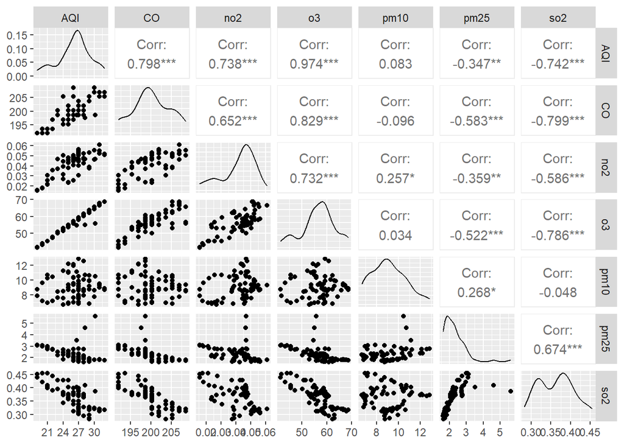

```r
GGally::ggpairs(aqi[sapply(aqi,is.numeric)])
```

Berdasarkan hasil matriks korelasi, dapat diketahui bahwa AQI memiliki nilai korelasi tertinggi dengan O3 yaitu sebesar $0.974$. Maka, akan dilakukan pemodelan regresi dengan peubah lag pada AQI sebagai peubah respon (Yt) dan O3 sebagai peubah bebas (Xt) sebagai berikut:

```r
aqi <- aqi[c(1,5)]
Xt <- aqi$o3
Yt <- aqi$AQI
data1 <- cbind(Yt,Xt)
data <- as.data.frame(data1)
data
```

```
##      Yt       Xt
## 1  30.2 55.78995
## 2  28.2 54.93164
## 3  26.6 54.64554
## 4  25.0 55.07469
## 5  26.0 55.78995
## 6  26.0 56.50520
## 7  26.0 55.78995
## 8  24.0 52.92892
## 9  23.0 50.06790
## 10 24.0 51.49841
## 11 25.0 53.64418
## 12 26.0 55.78995
## 13 27.0 59.36623
## 14 29.0 62.22725
```

[output cut: 58 more lines]

## Pembagian Data

Dilakukan splitting data dengan data training sebesar 80% dari jumlah seluruh amatan yaitu 57 amatan dan data testing sebesar 20% dari jumlah seluruh amatan yaitu 15 amatan.

```r
#Split Data (80% training data, 20% testing data)
train_data <- data[1:57,]
test_data <- data[58:72,]
```

Setelah dilakukan splitting data, kemudian mengubah kedua data menjadi format data time series.

```r
#Data Time Series
train.ts <- ts(train_data)
test.ts <- ts(test_data)
data.ts <- ts(data)
```

Berikut adalah plot training data dan testing data.

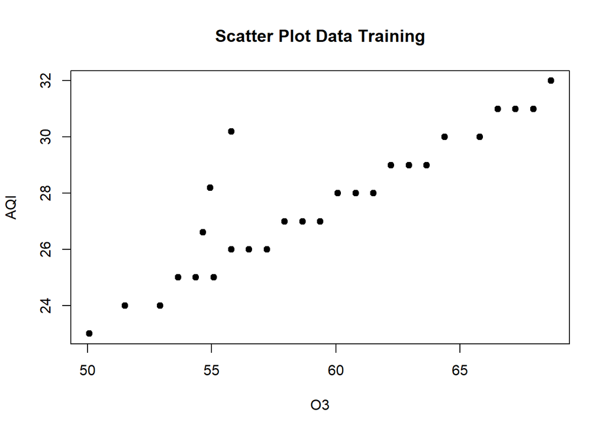

```r
#Plot Training Data
plot(train_data$Xt,train_data$Yt,pch = 19, main = "Scatter Plot Data Training", ylab = "AQI", xlab = "O3")
```

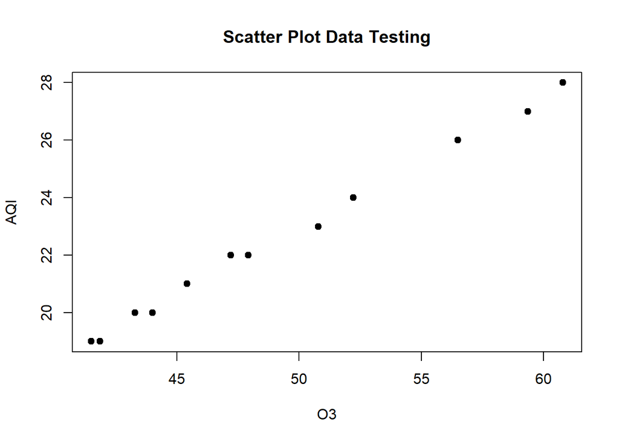

```r
#Plot Testing Data
plot(test_data$Xt,test_data$Yt,pch = 19, main = "Scatter Plot Data Testing", ylab = "AQI", xlab = "O3")
```

Berdasarkan plot yang dihasilkan. dapat terlihat bahwa kedua data memiliki pola yang mirip, ini mengindikasikan hal yang baik untuk menghindari terjadinya over/underfitting.

## Model Koyck

### Pemodelan

```r
model.koyck <- koyckDlm(x = train_data$Xt, y = train_data$Yt)
summary(model.koyck)
```

```
##
## Call:
## "Y ~ (Intercept) + Y.1 + X.t"
##
## Residuals:
##       Min        1Q    Median        3Q       Max
## -1.127670 -0.301407  0.001002  0.262601  1.103471
##
## Coefficients:
##             Estimate Std. Error t value Pr(>|t|)
## (Intercept)  0.54798    0.92878   0.590    0.558
## Y.1          0.41955    0.08223   5.102 4.63e-06 ***
## X.t          0.25830    0.04107   6.289 6.25e-08 ***
## ---
## Signif. codes:  0 '***' 0.001 '**' 0.01 '*' 0.05 '.' 0.1 ' ' 1
##
## Residual standard error: 0.5053 on 53 degrees of freedom
## Multiple R-Squared: 0.9463,  Adjusted R-squared: 0.9443
## Wald test: 423.7 on 2 and 53 DF,  p-value: < 2.2e-16
##
## Diagnostic tests:
## NULL
##
##                             alpha      beta       phi
## Geometric coefficients:  0.944071 0.2582957 0.4195528
```

Dari hasil tersebut, didapat bahwa peubah $x_t$ dan $y_{t-1}$ memiliki nilai $P-Value<0.05$. Hal ini menunjukkan bahwa peubah $x_t$ dan $y_{t-1}$ berpengaruh signifikan terhadap $y$ pada taraf nyata 5%. Artinya tingkat senyawa O3 pada periode saat ini dan nilai AQI pada satu periode sebelumnya mempengaruhi nilai AQI periode saat ini. Adapun model keseluruhannya adalah sebagai berikut:

$$\hat{Y_t}=0.54798+0.25830X_t+0.41955Y_{t-1}$$

### Peramalan dan Akurasi

```r
#Hasil Ramalan pada Model Koyck untuk 15 periode kedepan
fore.koyck <- forecast(model = model.koyck, x=test_data$Xt, h=15)
fore.koyck
```

```
## $forecasts
##  [1] 24.15387 23.05989 21.95429 21.12094 20.21706 19.74546 20.00947 20.67448
##  [9] 20.95348 21.07054 21.58152 23.08914 24.83015 26.29958 27.28558
##
## $call
## forecast.koyckDlm(model = model.koyck, x = test_data$Xt, h = 15)
##
## attr(,"class")
## [1] "forecast.koyckDlm" "dLagM"
```

Data di atas merupakan hasil peramalan AQI untuk 15 periode kedepan sesuai dengan jumlah amatan data testing, dengan menggunakan Model Koyck.

```r
#MAPE Testing Data
mape.koyck <- MAPE(fore.koyck$forecasts, test_data$Yt)

#Akurasi Training Data
mape.train <- dLagM::GoF(model.koyck)["MAPE"]

c("MAPE_testing" = mape.koyck, "MAPE_training" = mape.train)
```

```
## $MAPE_testing
## [1] 0.03187326
##
## $MAPE_training.MAPE
## [1] 0.01435646
```

Berdasarkan perhitungan MAPE di atas, terlihat bahwa nilai MAPE pada data forecasting yaitu sebesar $0.03187$ lebih besar dari nilai MAPE data training yaitu sebesar $0.01435$. Dapat dilihat juga bahwa nilai MAPE keduanya tidak jauh berbeda, yang berarti model regresi dengan model Koyck ini tidak overfitted atau underfitted. Model tersebut juga merupakan model yang sangat baik dengan nilai MAPE yang kurang dari 10%.

## Regression with Distributed Lag

### Pemodelan (Lag=2)

```r
model.dlm <- dlm(x = train_data$Xt,y = train_data$Yt , q = 2)
summary(model.dlm)
```

```
##
## Call:
## lm(formula = model.formula, data = design)
##
## Residuals:
##      Min       1Q   Median       3Q      Max
## -0.45678 -0.35809 -0.02571  0.25176  1.40513
##
## Coefficients:
##              Estimate Std. Error t value Pr(>|t|)
## (Intercept) -0.052782   0.689979  -0.076    0.939
## x.t          0.476379   0.053816   8.852 6.95e-12 ***
## x.1         -0.005756   0.099095  -0.058    0.954
## x.2         -0.008392   0.055411  -0.151    0.880
## ---
## Signif. codes:  0 '***' 0.001 '**' 0.01 '*' 0.05 '.' 0.1 ' ' 1
##
## Residual standard error: 0.3501 on 51 degrees of freedom
## Multiple R-squared:  0.9751, Adjusted R-squared:  0.9736
## F-statistic:   666 on 3 and 51 DF,  p-value: < 2.2e-16
##
## AIC and BIC values for the model:
##       AIC      BIC
## 1 46.4728 56.50947
```

```r
AIC(model.dlm)
```

```
## [1] 46.4728
```

```r
BIC(model.dlm)
```

```
## [1] 56.50947
```

Dari hasil diatas, didapat bahwa hanya $P-value$ dari $x_{t}<0.05$. Hal ini menunjukkan bahwa $x_{t}$ berpengaruh signifikan terhadap $y$ pada taraf nyata 5%. Artinya tingkat senyawa O3 periode saat ini mempengaruhi nilai AQI periode saat ini. Adapun model keseluruhan yang terbentuk adalah sebagai berikut:

$$\hat{Y_t}=-0.052782+0.476379X_t-0.005756X_{t-1}-0.008392X_{t-2}$$

### Peramalan dan Akurasi

```r
#Hasil Ramalan pada Model DLM untuk 15 periode kedepan
fore.dlm <- forecast(model = model.dlm, x=test_data$Xt, h=15)
fore.dlm
```

```
## $forecasts
##  [1] 23.34620 22.02786 20.88178 20.23873 19.24577 19.09976 19.97166 20.98657
##  [9] 20.95921 20.94120 21.79304 24.16788 26.16845 27.46467 28.09365
##
## $call
## forecast.dlm(model = model.dlm, x = test_data$Xt, h = 15)
##
## attr(,"class")
## [1] "forecast.dlm" "dLagM"
```

Data di atas merupakan hasil peramalan AQI untuk 15 periode kedepan sesuai dengan jumlah amatan data testing, dengan menggunakan Model Distributed Lag.

```r
#MAPE Testing Data
mape.dlm <- MAPE(fore.dlm$forecasts, test_data$Yt)

#Akurasi Training Data
mape.train <- dLagM::GoF(model.dlm)["MAPE"]

c("MAPE_testing" = mape.dlm, "MAPE_training" = mape.train)
```

```
## $MAPE_testing
## [1] 0.006820359
##
## $MAPE_training.MAPE
## [1] 0.00988322
```

Berdasarkan perhitungan MAPE di atas, terlihat bahwa nilai MAPE yang dihasilkan pada data forecasting yaitu sebesar $0.00682$ sudah lebih kecil dari nilai MAPE data training sebesar $0.00988$. Dapat dilihat juga bahwa nilai MAPE keduanya tidak jauh berbeda sehingga model regresi dengan distributed lag ini tidak overfitted atau underfitted. Model tersebut juga merupakan model yang sangat baik dengan nilai MAPE yang kurang dari 10%.

## Regression with Distributed Lag Optimum

### Penentuan Lag Optimum

```r
lag_optimum<-finiteDLMauto(formula=Yt ~ Xt,
              data = data.frame(train_data),model.type = "dlm",error.type = "AIC");lag_optimum
```

```
##    q - k    MASE      AIC      BIC    GMRAE   MBRAE R.Adj.Sq Ljung-Box
## 10    10 0.35051 22.97129 47.02321 14499.82 0.49589  0.98302  0.354745
```

Berdasarkan output tersebut, lag optimum didapatkan ketika lag = 10. Selanjutnya dilakukan pemodelan untuk lag = 10.

### Pemodelan (Lag Optimum)

```r
model.dlm2 <- dlm(x = train_data$Xt,y = train_data$Yt , q = 10)
summary(model.dlm2)
```

```
##
## Call:
## lm(formula = model.formula, data = design)
##
## Residuals:
##     Min      1Q  Median      3Q     Max
## -0.5204 -0.1663  0.0356  0.1624  0.5130
##
## Coefficients:
##              Estimate Std. Error t value Pr(>|t|)
## (Intercept) -0.294780   0.931786  -0.316  0.75361
## x.t          0.405638   0.063702   6.368 2.54e-07 ***
## x.1          0.159000   0.133129   1.194  0.24038
## x.2         -0.052741   0.126788  -0.416  0.67997
## x.3         -0.148621   0.121282  -1.225  0.22860
## x.4          0.143544   0.124404   1.154  0.25638
## x.5         -0.007047   0.123348  -0.057  0.95476
## x.6         -0.127683   0.123191  -1.036  0.30709
## x.7          0.287823   0.121937   2.360  0.02396 *
## x.8         -0.399437   0.121443  -3.289  0.00230 **
## x.9          0.304147   0.103813   2.930  0.00594 **
## x.10        -0.098958   0.048025  -2.061  0.04684 *
## ---
## Signif. codes:  0 '***' 0.001 '**' 0.01 '*' 0.05 '.' 0.1 ' ' 1
##
## Residual standard error: 0.2715 on 35 degrees of freedom
## Multiple R-squared:  0.9871, Adjusted R-squared:  0.983
## F-statistic: 243.1 on 11 and 35 DF,  p-value: < 2.2e-16
##
## AIC and BIC values for the model:
##        AIC      BIC
## 1 22.97129 47.02321
```

```r
AIC(model.dlm2)
```

```
## [1] 22.97129
```

```r
BIC(model.dlm2)
```

```
## [1] 47.02321
```

Dari hasil tersebut terdapat beberapa peubah yang berpengaruh signifikan terhadap $y$ pada taraf nyata 5% yaitu $x_t$ , $x_{t-7}$ , $x_{t-8}$ , $x_{t-9}$, dan $x_{t-10}$. Artinya nilai AQI periode saat ini dipengaruhi secara signifikan oleh tingkat senyawa O3 periode saat ini, tingkat senyawa O3 tujuh periode sebelumnya, tingkat senyawa O3 delapan periode sebelumnya, tingkat senyawa O3 sembilan periode sebelumnya dan tingkat senyawa O3 sepuluh periode sebelumnya. Adapun keseluruhan model yang terbentuk adalah:

$$\hat{Y_t}=-0.294780+0.405638X_t+...+0.287823X_{t-7}-0.399437X_{t-8}+0.304147X_{t-9}-0.098958X_{t-10}$$

### Peramalan dan Akurasi

```r
#Hasil Ramalan pada Model DLM Optimum untuk 15 periode kedepan
fore.dlm2 <- forecast(model = model.dlm2, x=test_data$Xt, h=15)
fore.dlm2
```

```
## $forecasts
##  [1] 23.40514 21.79122 20.75754 20.09325 19.25114 18.84865 19.56151 20.98076
##  [9] 21.17891 20.56410 21.57565 23.70751 26.47347 27.65902 27.98734
##
## $call
## forecast.dlm(model = model.dlm2, x = test_data$Xt, h = 15)
##
## attr(,"class")
## [1] "forecast.dlm" "dLagM"
```

Data di atas merupakan hasil peramalan AQI untuk 15 periode kedepan sesuai dengan jumlah amatan data testing, dengan menggunakan Model Distributed Lag Optimum.

```r
#MAPE Testing Data
mape.dlm2 <- MAPE(fore.dlm2$forecasts, test_data$Yt)

#Akurasi Training Data
mape.train <- dLagM::GoF(model.dlm2)["MAPE"]

c("MAPE_testing" = mape.dlm2, "MAPE_training" = mape.train)
```

```
## $MAPE_testing
## [1] 0.01274404
##
## $MAPE_training.MAPE
## [1] 0.007238929
```

Berdasarkan perhitungan MAPE di atas, terlihat bahwa nilai MAPE yang dihasilkan pada data forecasting yaitu sebesar $0.01274$ lebih besar dari nilai MAPE data training sebesar $0.00723$.Dapat dilihat juga bahwa MAPE keduanya tidak jauh berbeda sehingga tidak overfitted atau underfitted. Model tersebut juga merupakan model yang sangat baik dengan nilai MAPE yang kurang dari 10%.

## Model Autoregressive

### Pemodelan (p = 1, q = 1)

```r
model.ardl <- ardlDlm(x = train_data$Xt, y = train_data$Yt, p = 1 , q = 1)
summary(model.ardl)
```

```
##
## Time series regression with "ts" data:
## Start = 2, End = 57
##
## Call:
## dynlm(formula = as.formula(model.text), data = data, start = 1)
##
## Residuals:
##     Min      1Q  Median      3Q     Max
## -1.0261 -0.2582  0.1254  0.2988  0.8683
##
## Coefficients:
##             Estimate Std. Error t value Pr(>|t|)
## (Intercept) -0.14906    0.67926  -0.219    0.827
## X.t          0.47821    0.03429  13.946  < 2e-16 ***
## X.1         -0.22331    0.04692  -4.759 1.59e-05 ***
## Y.1          0.45264    0.06656   6.801 1.03e-08 ***
## ---
## Signif. codes:  0 '***' 0.001 '**' 0.01 '*' 0.05 '.' 0.1 ' ' 1
##
## Residual standard error: 0.3812 on 52 degrees of freedom
## Multiple R-squared:   0.97,  Adjusted R-squared:  0.9683
## F-statistic: 561.2 on 3 and 52 DF,  p-value: < 2.2e-16
```

```r
AIC(model.ardl)
```

```
## [1] 56.75817
```

```r
BIC(model.ardl)
```

```
## [1] 66.88493
```

Hasil di atas menunjukkan bahwa $x_t$, $x_{t-1}$, dan $y_{t-1}$ berpengaruh signifikan terhadap $y$ pada taraf nyata 5%, yang berarti tingkat senyawa O3 periode saat ini, tingkat senyawa O3 satu periode sebelumnya, dan nilai AQI satu periode sebelumnya, ketiganya mempengaruhi nilai AQI periode saat ini. Model keseluruhannya adalah sebagai berikut:

$$\hat{Y}=-0.14906+0.47821X_t-0.22331X_{t-1}+0.45264Y_{t-1}$$

### Peramalan dan Akurasi

```r
#Hasil ramalan pada Model Autoregressive untuk 15 periode kedepan
fore.ardl <- forecast(model = model.ardl, x=test_data$Xt, h=15)
fore.ardl
```

```
## $forecasts
##  [1] 23.31352 21.98057 20.81893 20.16806 19.16675 19.02165 19.89095 20.91127
##  [9] 20.89394 20.88610 21.73767 24.11814 26.12988 27.45034 28.09325
##
## $call
## forecast.ardlDlm(model = model.ardl, x = test_data$Xt, h = 15)
##
## attr(,"class")
## [1] "forecast.ardlDlm" "dLagM"
```

Data di atas merupakan hasil peramalan untuk 15 periode kedepan menggunakan Model Autoregressive dengan $p=1$ dan $q=1$.

```r
#MAPE Testing Data
mape.ardl <- MAPE(fore.ardl$forecasts, test_data$Yt)

#Akurasi Training Data
mape.train <- dLagM::GoF(model.ardl)["MAPE"]

c("MAPE_testing" = mape.ardl, "MAPE_training" = mape.train)
```

```
## $MAPE_testing
## [1] 0.006897306
##
## $MAPE_training.MAPE
## [1] 0.01160232
```

Berdasarkan perhitungan MAPE di atas, terlihat bahwa nilai MAPE data forecasting yaitu sebesar $0.00689$ sudah lebih kecil dari nilai MAPE data training sebesar $0.01160$. Dapat dilihat juga bahwa MAPE keduanya tidak jauh berbeda. Artinya, model regresi dengan Autogressive ini tidak overfitted atau underfitted. Model tersebut juga merupakan model yang sangat baik dengan nilai MAPE yang kurang dari 10%.

## Model Autoregressive Optimum

### Mencari parameter p dan q yang optimum

```r
model.ardl.opt <- ardlBoundOrders(data = data.frame(data), ic = "AIC",
                                  formula = Yt ~ Xt )
min_p=c()
for(i in 1:6){
  min_p[i]=min(model.ardl.opt$Stat.table[[i]])
}
q_opt=which(min_p==min(min_p, na.rm = TRUE))
p_opt=which(model.ardl.opt$Stat.table[[q_opt]] ==
              min(model.ardl.opt$Stat.table[[q_opt]], na.rm = TRUE))
data.frame("q_optimum" = q_opt, "p_optimum" = p_opt,
           "AIC"=model.ardl.opt$min.Stat)
```

```
##   q_optimum p_optimum      AIC
## 1         2        13 16.55044
```

Dari tabel di atas, dapat terlihat bahwa nilai AIC terendah didapat ketika $p=13$ dan $q=2$, yaitu sebesar $16.55044$. Artinya, model autoregressive optimum didapat ketika $p=13$ dan $q=2$.

Selanjutnya dapat dilakukan pemodelan dengan nilai $p$ dan $q$ optimum seperti inisialisasi di langkah sebelumnya.

### Pemodelan Autoregressive Optimum

```r
model.ardl2 = ardlDlm(x = train_data$Xt, y = train_data$Yt, p = 13, q = 2)
summary(model.ardl2)
```

```
##
## Time series regression with "ts" data:
## Start = 14, End = 57
##
## Call:
## dynlm(formula = as.formula(model.text), data = data, start = 1)
##
## Residuals:
##      Min       1Q   Median       3Q      Max
## -0.45939 -0.19244  0.04237  0.18424  0.45823
##
## Coefficients:
##             Estimate Std. Error t value Pr(>|t|)
## (Intercept) -0.77136    1.12356  -0.687   0.4982
## X.t          0.39407    0.07142   5.517 7.61e-06 ***
## X.1          0.20786    0.18280   1.137   0.2655
## X.2         -0.02966    0.21795  -0.136   0.8928
## X.3         -0.13619    0.16006  -0.851   0.4023
## X.4          0.05226    0.16212   0.322   0.7497
## X.5          0.04957    0.14512   0.342   0.7353
## X.6         -0.13909    0.13618  -1.021   0.3162
## X.7          0.27019    0.13651   1.979   0.0581 .
## X.8         -0.31492    0.14669  -2.147   0.0409 *
## X.9          0.15294    0.16112   0.949   0.3509
## X.10         0.09506    0.16928   0.562   0.5790
## X.11        -0.16098    0.15567  -1.034   0.3103
## X.12         0.04585    0.12175   0.377   0.7094
## X.13         0.01492    0.05471   0.273   0.7871
## Y.1         -0.12772    0.19313  -0.661   0.5140
## Y.2          0.06633    0.21010   0.316   0.7546
## ---
## Signif. codes:  0 '***' 0.001 '**' 0.01 '*' 0.05 '.' 0.1 ' ' 1
##
## Residual standard error: 0.2868 on 27 degrees of freedom
## Multiple R-squared:  0.9884, Adjusted R-squared:  0.9814
## F-statistic: 143.2 on 16 and 27 DF,  p-value: < 2.2e-16
```

Hasil di atas menunjukkan bahwa hanya $x_t$ dan $x_{t-8}$ yang berpengaruh signifikan terhadap $y$ pada taraf nyata 5%, yang berarti tingkat senyawa O3 periode saat ini dan tingkat senyawa O3 delapan periode sebelumnya mempengaruhi nilai AQI periode saat ini. Model keseluruhannya adalah sebagai berikut:

$$\hat{Y}=-0.77136+0.39407X_t+0.20786X_{t-1}+...-0.12772Y_{t-1}+0.06633Y_{t-2}$$

### Peramalan dan Akurasi

```r
#Hasil Ramalan pada Model Autoregressive Optimum untuk 15 periode kedepan dengan p = 13, q = 2
fore.ardl2 <- forecast(model = model.ardl2, x=test_data$Xt, h=15)
fore.ardl2
```

```
## $forecasts
##  [1] 23.31655 21.80904 20.61682 20.06357 19.24186 18.82466 19.48054 20.86204
##  [9] 21.19795 20.60591 21.49901 23.57998 26.28620 27.75765 28.02269
##
## $call
## forecast.ardlDlm(model = model.ardl2, x = test_data$Xt, h = 15)
##
## attr(,"class")
## [1] "forecast.ardlDlm" "dLagM"
```

Data di atas merupakan hasil peramalan untuk 15 periode kedepan menggunakan Model Autoregressive Optimum dengan $p=13$ dan $q=2$.

```r
#MAPE Testing Data
mape.ardl2 <- MAPE(fore.ardl2$forecasts, test_data$Yt)

#Akurasi Training Data
mape.train <- dLagM::GoF(model.ardl2)["MAPE"]

c("MAPE_testing" = mape.ardl2, "MAPE_training" = mape.train)
```

```
## $MAPE_testing
## [1] 0.01378089
##
## $MAPE_training.MAPE
## [1] 0.007069452
```

Berdasarkan perhitungan MAPE di atas, terlihat bahwa nilai MAPE data forecasting yaitu sebesar $0.01378$ lebih besar dari nilai MAPE data training sebesar $0.00706$. Nilai MAPE keduanya juga tidak jauh berbeda. Artinya, model regresi dengan Autoregressive Optimum ini tidak overfitted atau underfitted. Model tersebut juga merupakan model yang sangat baik dengan nilai MAPE yang kurang dari 10%.

## Perbandingan Model

```r
accurate <- matrix(c(mape.koyck, mape.dlm, mape.dlm2, mape.ardl, mape.ardl2))
row.names(accurate)<- c("Koyck","DLM","DLM Optimum","Autoregressive", "Autoregressive Optimum")
colnames(accurate) <- c("MAPE")
accurate
```

```
##                               MAPE
## Koyck                  0.031873255
## DLM                    0.006820359
## DLM Optimum            0.012744036
## Autoregressive         0.006897306
## Autoregressive Optimum 0.013780887
```

Berdasarkan nilai MAPE, model paling optimum didapat pada Model DLM karena memiliki nilai MAPE yang terkecil.

## Plot

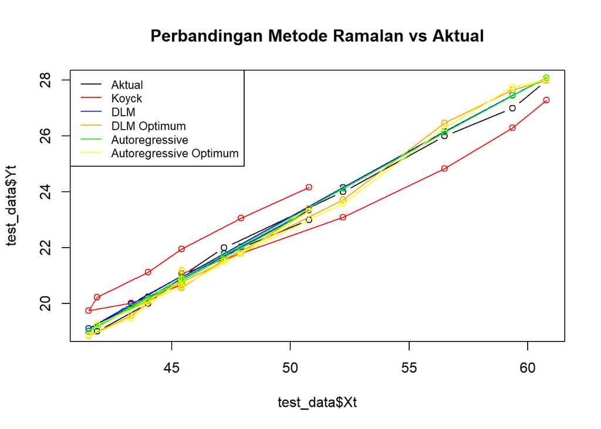

```r
par(mfrow=c(1,1))
plot(test_data$Xt, test_data$Yt, type="b", col="black",main="Perbandingan Metode Ramalan vs Aktual")
points(test_data$Xt, fore.koyck$forecasts,col="red")
lines(test_data$Xt, fore.koyck$forecasts,col="red")
points(test_data$Xt, fore.dlm$forecasts,col="blue")
lines(test_data$Xt, fore.dlm$forecasts,col="blue")
points(test_data$Xt, fore.dlm2$forecasts,col="orange")
lines(test_data$Xt, fore.dlm2$forecasts,col="orange")
points(test_data$Xt, fore.ardl$forecasts,col="green")
lines(test_data$Xt, fore.ardl$forecasts,col="green")
points(test_data$Xt, fore.ardl2$forecasts,col="yellow")
lines(test_data$Xt, fore.ardl2$forecasts,col="yellow")
legend("topleft",c("Aktual", "Koyck","DLM","DLM Optimum", "Autoregressive", "Autoregressive Optimum"), lty=1, col=c("black","red","blue","orange","green","yellow"), cex=0.8)
```

Berdasarkan plot tersebut, terlihat bahwa plot yang paling mendekati data aktualnya adalah Model DLM, sehingga dapat disimpulkan model terbaik dalam hal ini adalah model regresi DLM.